# Amr Mohammad Soliman

### Plot Three

##### Relationship between Delinquencies and Employment Status

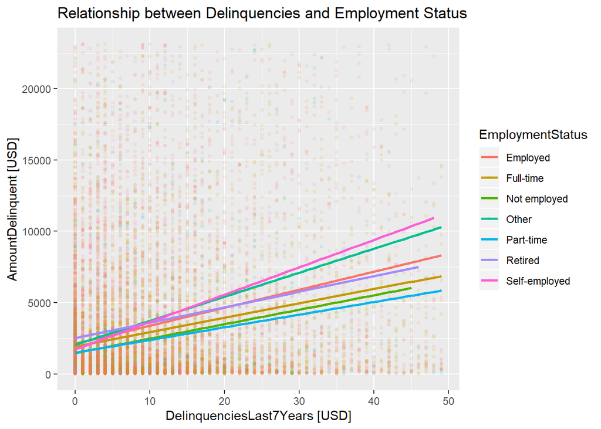

# Reflection

- This was somehow challenging but a good way to have a firm  
  grasp on doing exploratory data analysis with R. much  
  more difficult than I thought it would be.Specially it was hard  
  to get started without any financial knowledge., but in the end,  
  it was incredibly rewarding.
- A simple way to show relationships among multi variables  
  is to add colors to the plot. Using different colors to  
  represent factorial variables. The point size of the scatter  
  plot can also be used to represent numerical variables with  
  larger size associated with larger numerical values.
- In the future, I think the analysis could be expanded to  
  try to predict interestrates on new loans.I think there is  
  enough information from the propser data that when combined  
  with general market yield curves, it could come close to  
  providing some prediction on where new loans would be given  
  a set of borrower characteristics.
- The followings are some of the interesting features which  
  I observed during the exploratory analysis:
  - Most of borrowers Income ranges from 25,000 - 74,999.
  - There are 3 loan terms 12, 36 and 60 months and the most popular one is 36 month.
  - Borrower who home owner usually receive bigger loan than others.
  - Employed person are more likley to take loan than others.
  - Homeowners usually have lower risk of making defaulted loans since bank can use their house as collateral.

# References

- http://www.cookbook-r.com
- https://www.statmethods.net/index.html
- https://www.r-bloggers.com
- http://www.r-tutor.com
- https://jianru-shi.github.io/Prosper_Loan_EDA/Prosper_Loan_EDA.html